# Series de tiempo: análisis descriptivo básico

Prof. Elizabeth Martínez Gómez

Módulo 2: Series de tiempo

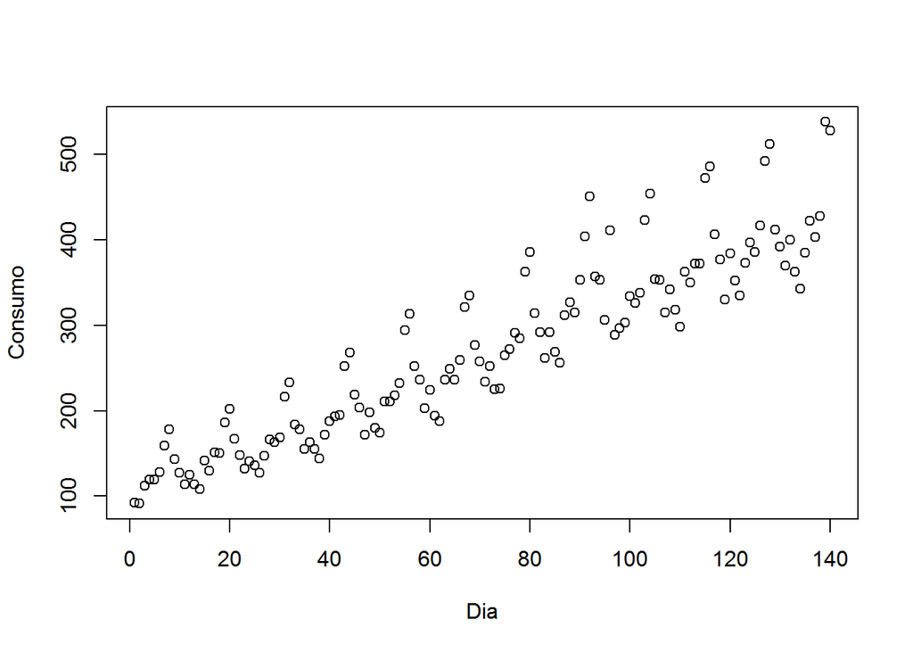

```r
setwd("G:/Academia/Docencia/Cursos TEC/MA1031 Análisis estadístico")
gas = read.table("./Datos/gas.dat",header=T)
attach(gas)
plot(Dia,Consumo)
```

¿Es adecuado el tipo de gráfico?

Mmmmm no….

Vemos que el gráfico resultante no es el más apropiado para describir una serie temporal. Si queremos que R trate a un objeto como serie temporal, tenemos que determinar apropiadamente sus características con el comando *ts*. Para definir la serie correctamente escribimos:

```r
gas.ts = ts(gas$Consumo, start = c(1966,1), frequency = 12)
```

El argumento *frequency* se utiliza para indicar la periodicidad de la serie (en este caso mensual), mientras que el argumento *start* indica la fecha de la primera observación (enero de 1966).

```r
print(gas.ts)
```

```
##        Jan   Feb   Mar   Apr   May   Jun   Jul   Aug   Sep   Oct   Nov   Dec
## 1966  92.7  91.4 112.0 119.0 119.0 128.0 159.0 178.0 143.0 127.0 114.0 125.0
## 1967 114.0 108.0 142.0 130.0 151.0 150.0 186.0 202.0 167.0 148.0 132.0 141.0
## 1968 136.0 127.0 147.0 166.0 163.0 169.0 216.0 233.0 184.0 178.0 155.0 163.0
## 1969 155.0 144.0 172.0 188.0 193.0 195.0 252.0 268.0 219.0 204.0 172.0 198.0
## 1970 180.0 174.0 211.0 211.0 218.0 232.0 294.0 313.0 252.0 236.0 203.0 224.0
## 1971 194.0 188.0 236.0 249.0 236.0 259.0 321.0 335.0 277.0 258.0 234.0 252.0
## 1972 225.0 226.0 265.0 272.0 291.0 285.0 363.0 386.0 314.0 292.0 262.0 292.0
## 1973 269.0 256.0 312.0 327.0 315.0 353.0 404.0 451.0 357.0 353.0 306.0 411.0
## 1974 289.0 297.0 303.0 334.0 326.0 338.0 423.0 454.0 354.0 353.0 315.0 342.0
## 1975 318.0 298.0 363.0 350.0 372.0 372.0 472.0 486.0 406.0 377.0 330.0 384.0
## 1976 352.0 335.0 373.0 397.0 386.0 417.0 492.0 512.0 412.0 392.0 370.0 400.0
## 1977 363.0 343.0 385.0 422.0 403.0 428.0 538.0 528.0
```

Ahora sí, graficamos:

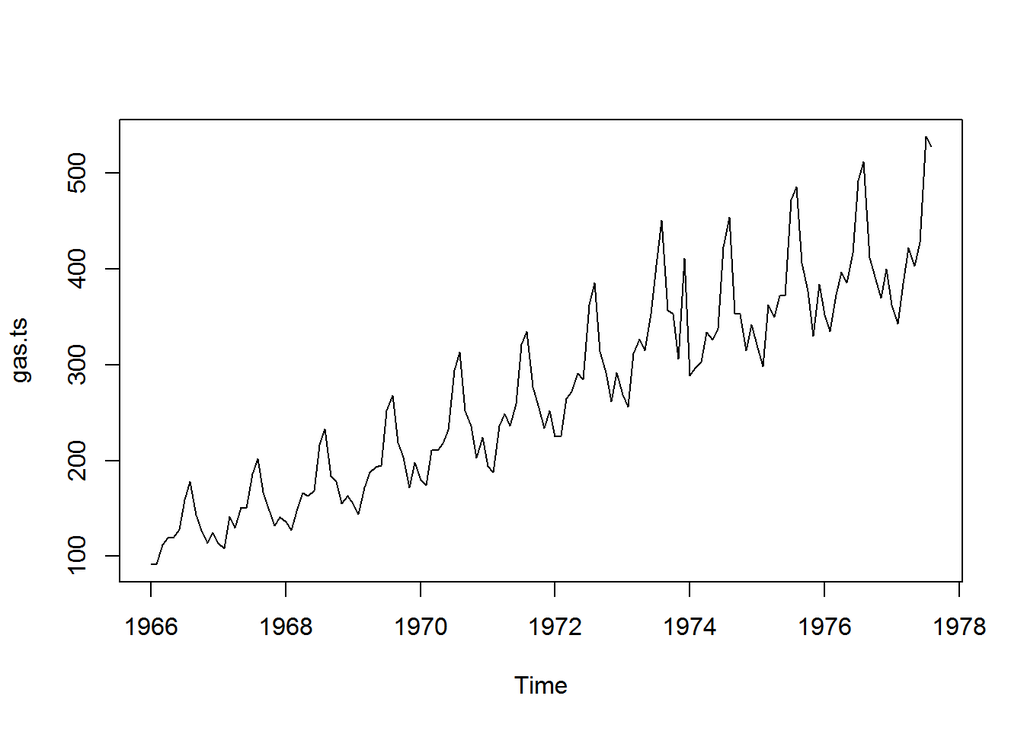

```r
plot(gas.ts)
```

Vemos ahora cómo el resultado depende de las características que hemos definido para la serie. Si queremos comparar la distribución del consumo de gasolina para cada mes, un gráfico útil es:

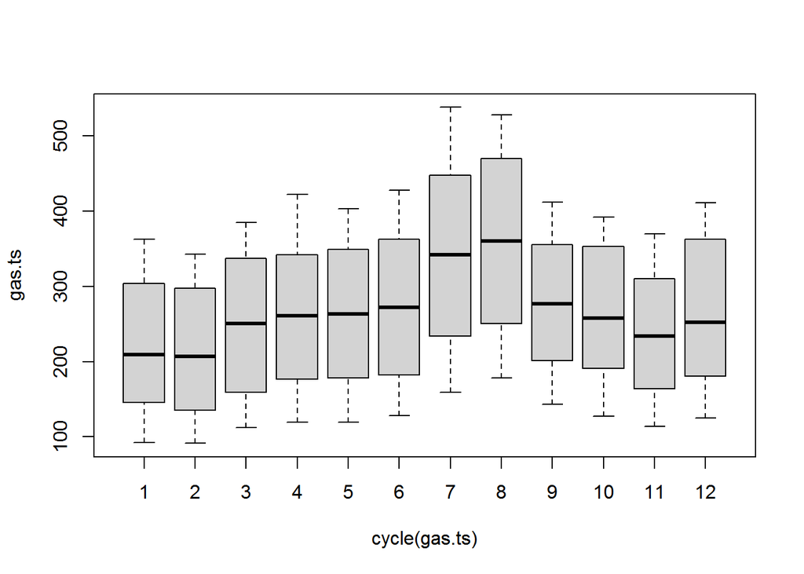

```r
boxplot(gas.ts ~ cycle(gas.ts))
```

El comando *cycle* determina la unidad de tiempo a la que pertenece cada observación de la serie:

```r
cycle(gas.ts)
```

```
##      Jan Feb Mar Apr May Jun Jul Aug Sep Oct Nov Dec
## 1966   1   2   3   4   5   6   7   8   9  10  11  12
## 1967   1   2   3   4   5   6   7   8   9  10  11  12
## 1968   1   2   3   4   5   6   7   8   9  10  11  12
## 1969   1   2   3   4   5   6   7   8   9  10  11  12
## 1970   1   2   3   4   5   6   7   8   9  10  11  12
## 1971   1   2   3   4   5   6   7   8   9  10  11  12
## 1972   1   2   3   4   5   6   7   8   9  10  11  12
## 1973   1   2   3   4   5   6   7   8   9  10  11  12
## 1974   1   2   3   4   5   6   7   8   9  10  11  12
## 1975   1   2   3   4   5   6   7   8   9  10  11  12
## 1976   1   2   3   4   5   6   7   8   9  10  11  12
## 1977   1   2   3   4   5   6   7   8
```

Por lo tanto, en el gráfico anterior se ha producido un diagrama de caja-brazos para cada mes del año.

**Actividad:**

El fichero datos_J&J.csv contiene los beneficios trimestrales de la empresa Johnson & Johnson entre 1960 y 1980.

Define la serie temporal y represéntala. ¿Cuál es el valor de la serie para el tercer trimestre de 1980? ¿Cuáles son las principales características (tendencia, estacionalidad) de esta serie?

# 1 Descomposición de una serie

Es frecuente analizar las series temporales desde el punto de vista de sus componentes estructurales:

Serie observada = Tendencia + Efecto estacional + Residuos.

En este modelo, la serie observada es el resultado de sumar una tendencia que representa el comportamiento a largo plazo de la serie, un efecto estacional que describe sus fluctuaciones periódicas y un componente residual que describe las variaciones a corto plazo, normalmente impredecibles.

Con R es muy sencillo obtener una descomposición estructural de este tipo. Se usa el comando *decompose*:

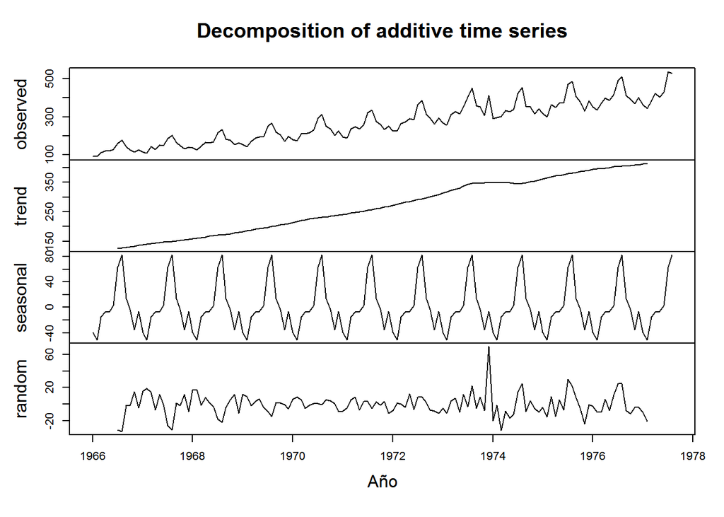

```r
gas.ts.desc = decompose(gas.ts)
plot(gas.ts.desc, xlab='Año')
```

Esta descomposición se basa en métodos elementales: la tendencia se calcula con una media móvil, el efecto estacional se calcula promediando los valores de cada unidad de tiempo para todos los periodos (por ejemplo, todos los meses de enero si la serie es mensual) y luego centrando el resultado. Finalmente, los residuos se obtienen restando a la serie observada las dos componentes anteriores. La descomposición solo es totalmente adecuada si se dispone de un número completo de periodos (por ejemplo, un múltiplo de 12 si la serie es mensual).

Si queremos “eliminar” la componente estacional de nuestra serie temporal, y dejar solamente la componente de tendencia y el ruido, basta con restar a la serie original la parte estacional (gas.ts.desc$seasonal) que acabamos de calcular:

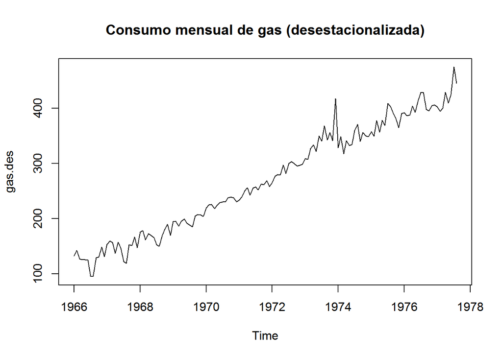

```r
gas.des=gas.ts-gas.ts.desc$seasonal
plot(gas.des,main="Consumo mensual de gas (desestacionalizada)")
```

# 2 Transformaciones básicas de una serie

En el gráfico de **gas.ts** se observa que la serie *no es estacionaria*.

¿Por qué? Porque la serie presenta una tendencia aparentemente lineal y una estacionalidad muy marcada (el consumo aumenta durante los meses de verano). Además, la amplitud de las fluctuaciones aumenta con el tiempo por lo que la variabilidad tampoco es constante.

Sin embargo, muchos modelos importantes de series temporales corresponden a series estacionarias (es decir, sin tendencia ni estacionalidad y con variabilidad constante). Antes de ajustar un modelo estacionario tenemos que transformar la serie original.

1. Estabilización de la varianza

Para estabilizar la variabilidad se suelen tomar logaritmos. Esta transformación funcionará bien cuando la variabilidad sea aproximadamente proporcional al nivel de la serie. Representamos la serie transformada mediante

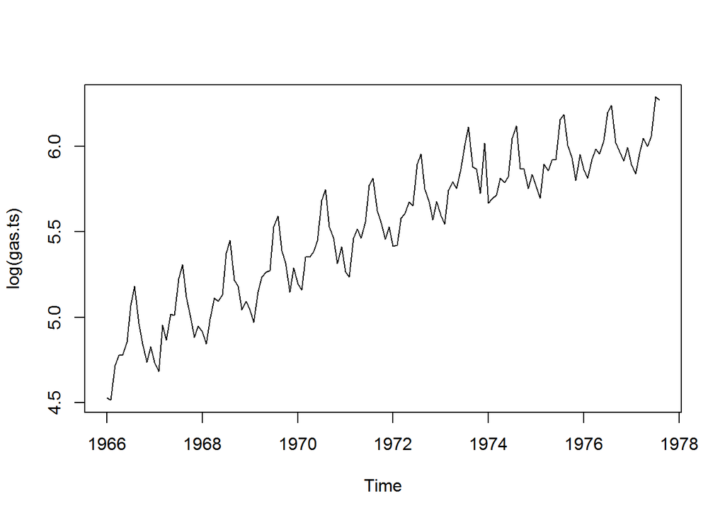

```r
plot(log(gas.ts))
```

2. Eliminación de tendencia: Una forma sencilla de eliminar una tendencia aproximadamente lineal es diferenciar la serie, es decir, considerar la serie de diferencias entre una observación y la anterior en lugar de la serie original.

Si $x_t$ es una serie contenida en $x$, para calcular $\Delta x_t=x_t−x_{t−1}$ con R se escribe:

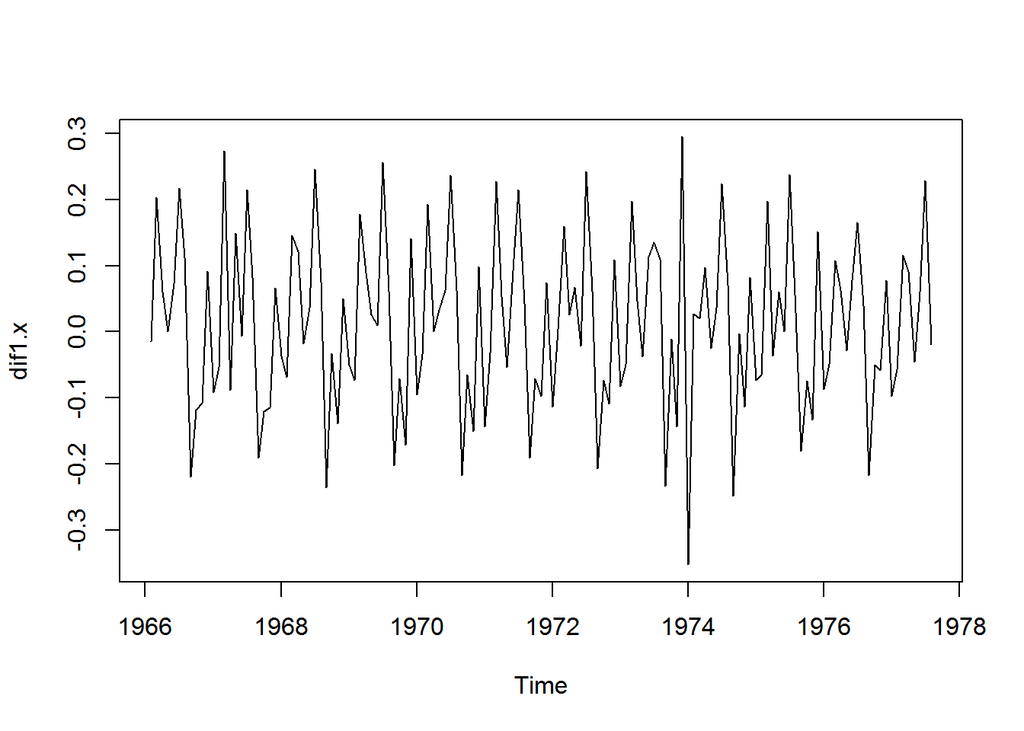

```r
x = log(gas.ts)
dif1.x = diff(x)
plot(dif1.x)
```

3. Eliminación de estacionalidad: Para eliminar la estacionalidad de una serie mensual se pueden tomar diferencias estacionales de orden 12. Si $x_t$ es la serie que queremos desestacionalizar, se trata de calcular $\Delta x_t=x_t−x_{t−12}$:

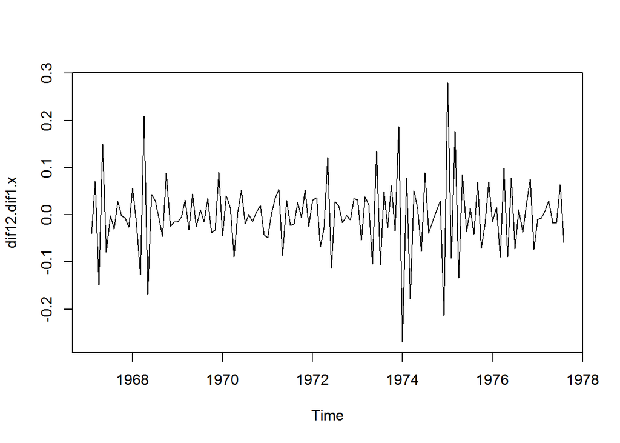

```r
dif12.dif1.x = diff(dif1.x, lag=12)
plot(dif12.dif1.x)
```

**Actividad: Aplica las transformaciones adecuadas a la serie de beneficios de la empresa Johnson & Johnson para obtener una serie aproximadamente estacionaria.**

# 3 Funciones de autocovarianzas y de autocorrelaciones

Transformamos la serie del consumo de gasolina de manera que un modelo estacionario sea apropiado para la serie transformada. El siguiente código se puede utilizar para representar el correlograma de la serie.

El correlograma es una representación gráfica de las autocorrelaciones $\rho(k)$, es decir, las correlaciones entre $x_t$ y $x_{t+k}$, en función de $k$:

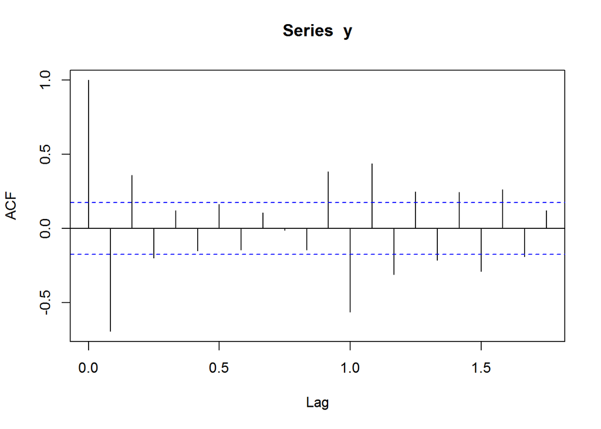

```r
y = dif12.dif1.x
acf(y)
```

Siempre se tiene que $\rho(0)=1$. Las líneas punteadas representan las bandas de confianza de $\rho(k)$ de nivel 95% bajo la hipótesis de que la serie es un ruido blanco (no correlacionada).

En el ejemplo las autocorrelaciones más significativas son las correlaciones entre la observación de un mes y la del mes siguiente, y la observación de un mes con la del mismo mes del año siguiente.

Si lo que queremos obtener son los valores numéricos de las correlaciones estimadas escribimos

```r
acf(y, plot=FALSE)$acf
```

```
## , , 1
##
##              [,1]
##  [1,]  1.00000000
##  [2,] -0.69382982
##  [3,]  0.35876501
##  [4,] -0.19804595
##  [5,]  0.12166405
##  [6,] -0.14981182
##  [7,]  0.16318219
##  [8,] -0.14561575
##  [9,]  0.10723974
## [10,] -0.01070779
## [11,] -0.14339263
## [12,]  0.38185826
## [13,] -0.56211403
## [14,]  0.43707930
## [15,] -0.31095228
## [16,]  0.24768575
## [17,] -0.21271401
## [18,]  0.24550128
## [19,] -0.28858858
## [20,]  0.26146640
## [21,] -0.19028786
## [22,]  0.12161449
```

# 4 Ruido blanco

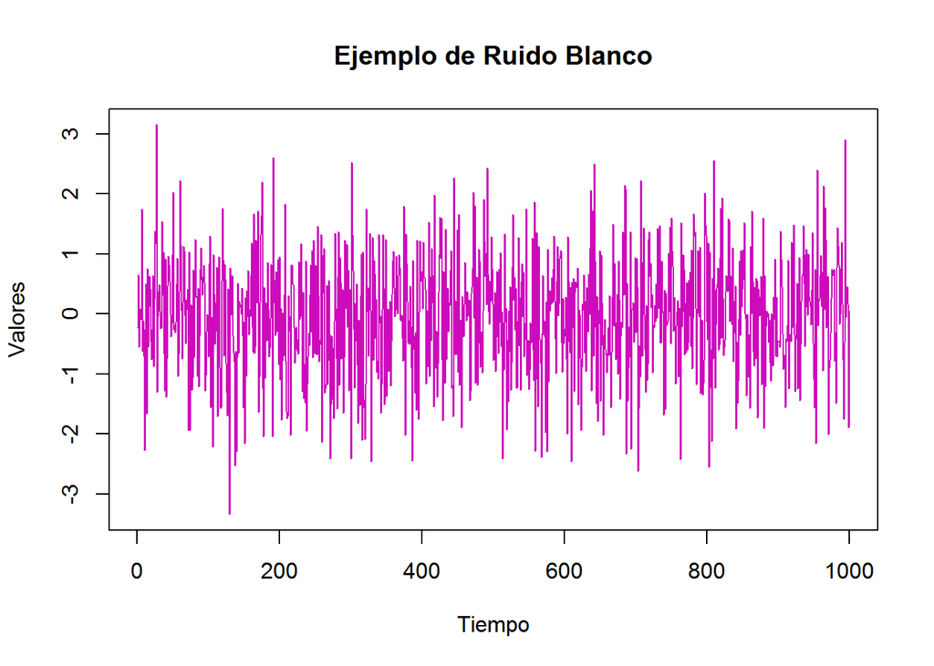

```r
ruido_blanco=rnorm(1000,0,1)
plot.ts(ruido_blanco, main="Ejemplo de Ruido Blanco", xlab="Tiempo", ylab="Valores",col="6")
```

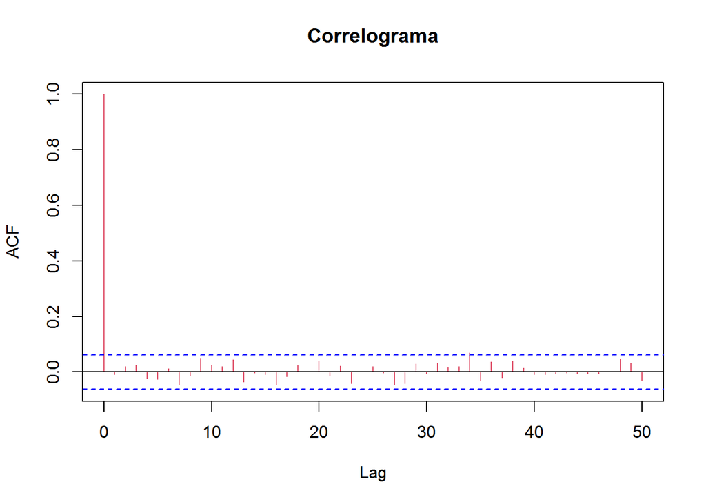

```r
acf(ruido_blanco,main="Correlograma",col="2",lag=50)
```

```r
mean(ruido_blanco)
```

```
## [1] -0.04732348
```

```r
Box.test(ruido_blanco)  # prueba de hipotesis para verificar si es ruido blanco
```

```
##
##  Box-Pierce test
##
## data:  ruido_blanco
## X-squared = 0.087942, df = 1, p-value = 0.7668
```

**Actividad: Representa el correlograma de la serie de beneficios de Johnson & Johnson transformada que se ha obtenido en el ejercicio anterior. ¿Podemos decir que la serie transformada es un ruido blanco?**